# Risk Factor Analysis

## Outcome Variable

**Outcome Variable:** haz

## Predictor Variables

**Intervention Variable:** impfloor

**Adjustment Set:**

- arm
- sex
- W_mage
- meducyrs
- feducyrs
- hhwealth_quart
- hfoodsec
- W_mhtcm
- W_mwtkg
- W_mbmi
- W_nrooms
- W_nchldlt5
- W_parity
- impsan
- safeh20
- delta_W_mage
- delta_meducyrs
- delta_feducyrs
- delta_hhwealth_quart
- delta_hfoodsec
- delta_W_mhtcm
- delta_W_mwtkg
- delta_W_mbmi
- delta_W_nrooms
- delta_W_nchldlt5
- delta_W_parity
- delta_impsan
- delta_safeh20

## Stratifying Variables

The analysis was stratified on these variable(s):

- agecat
- studyid
- country

## Data Summary

| agecat | studyid | country | impfloor | n_cell | n | outcome_variable |
| --- | --- | --- | --- | --- | --- | --- |
| Birth | ki0047075b-MAL-ED | BANGLADESH | 1 | 196 | 213 | haz |
| Birth | ki0047075b-MAL-ED | BANGLADESH | 0 | 17 | 213 | haz |
| Birth | ki0047075b-MAL-ED | BRAZIL | 1 | 58 | 60 | haz |
| Birth | ki0047075b-MAL-ED | BRAZIL | 0 | 2 | 60 | haz |
| Birth | ki0047075b-MAL-ED | INDIA | 1 | 35 | 41 | haz |
| Birth | ki0047075b-MAL-ED | INDIA | 0 | 6 | 41 | haz |
| Birth | ki0047075b-MAL-ED | NEPAL | 1 | 9 | 25 | haz |
| Birth | ki0047075b-MAL-ED | NEPAL | 0 | 16 | 25 | haz |
| Birth | ki0047075b-MAL-ED | PERU | 1 | 39 | 215 | haz |
| Birth | ki0047075b-MAL-ED | PERU | 0 | 176 | 215 | haz |
| Birth | ki0047075b-MAL-ED | SOUTH AFRICA | 1 | 87 | 96 | haz |
| Birth | ki0047075b-MAL-ED | SOUTH AFRICA | 0 | 9 | 96 | haz |
| Birth | ki0047075b-MAL-ED | TANZANIA, UNITED REPUBLIC OF | 1 | 7 | 119 | haz |
| Birth | ki0047075b-MAL-ED | TANZANIA, UNITED REPUBLIC OF | 0 | 112 | 119 | haz |
| Birth | ki1000108-CMC-V-BCS-2002 | INDIA | 1 | 72 | 72 | haz |
| Birth | ki1000108-CMC-V-BCS-2002 | INDIA | 0 | 0 | 72 | haz |
| Birth | ki1000108-IRC | INDIA | 1 | 287 | 287 | haz |
| Birth | ki1000108-IRC | INDIA | 0 | 0 | 287 | haz |
| Birth | ki1017093-NIH-Birth | BANGLADESH | 1 | 533 | 605 | haz |
| Birth | ki1017093-NIH-Birth | BANGLADESH | 0 | 72 | 605 | haz |
| Birth | ki1017093b-PROVIDE | BANGLADESH | 1 | 491 | 539 | haz |
| Birth | ki1017093b-PROVIDE | BANGLADESH | 0 | 48 | 539 | haz |
| Birth | ki1017093c-NIH-Crypto | BANGLADESH | 1 | 558 | 732 | haz |
| Birth | ki1017093c-NIH-Crypto | BANGLADESH | 0 | 174 | 732 | haz |
| Birth | ki1113344-GMS-Nepal | NEPAL | 1 | 100 | 544 | haz |
| Birth | ki1113344-GMS-Nepal | NEPAL | 0 | 444 | 544 | haz |
| Birth | ki1114097-CONTENT | PERU | 1 | 2 | 2 | haz |
| Birth | ki1114097-CONTENT | PERU | 0 | 0 | 2 | haz |
| Birth | kiGH5241-JiVitA-3 | BANGLADESH | 1 | 1394 | 22399 | haz |
| Birth | kiGH5241-JiVitA-3 | BANGLADESH | 0 | 21005 | 22399 | haz |

[output cut: 66 more lines]

The following strata were considered:

- agecat: 24 months, studyid: ki0047075b-MAL-ED, country: BANGLADESH
- agecat: 24 months, studyid: ki0047075b-MAL-ED, country: BRAZIL
- agecat: 24 months, studyid: ki0047075b-MAL-ED, country: INDIA
- agecat: 24 months, studyid: ki0047075b-MAL-ED, country: NEPAL
- agecat: 24 months, studyid: ki0047075b-MAL-ED, country: PERU
- agecat: 24 months, studyid: ki0047075b-MAL-ED, country: SOUTH AFRICA
- agecat: 24 months, studyid: ki0047075b-MAL-ED, country: TANZANIA, UNITED REPUBLIC OF
- agecat: 24 months, studyid: ki1000108-CMC-V-BCS-2002, country: INDIA
- agecat: 24 months, studyid: ki1000108-IRC, country: INDIA
- agecat: 24 months, studyid: ki1017093-NIH-Birth, country: BANGLADESH
- agecat: 24 months, studyid: ki1017093b-PROVIDE, country: BANGLADESH
- agecat: 24 months, studyid: ki1017093c-NIH-Crypto, country: BANGLADESH
- agecat: 24 months, studyid: ki1113344-GMS-Nepal, country: NEPAL
- agecat: 24 months, studyid: ki1114097-CONTENT, country: PERU
- agecat: 24 months, studyid: kiGH5241-JiVitA-3, country: BANGLADESH
- agecat: 24 months, studyid: kiGH5241-JiVitA-4, country: BANGLADESH
- agecat: 6 months, studyid: ki0047075b-MAL-ED, country: BANGLADESH
- agecat: 6 months, studyid: ki0047075b-MAL-ED, country: BRAZIL
- agecat: 6 months, studyid: ki0047075b-MAL-ED, country: INDIA
- agecat: 6 months, studyid: ki0047075b-MAL-ED, country: NEPAL
- agecat: 6 months, studyid: ki0047075b-MAL-ED, country: PERU
- agecat: 6 months, studyid: ki0047075b-MAL-ED, country: SOUTH AFRICA
- agecat: 6 months, studyid: ki0047075b-MAL-ED, country: TANZANIA, UNITED REPUBLIC OF
- agecat: 6 months, studyid: ki1000108-CMC-V-BCS-2002, country: INDIA
- agecat: 6 months, studyid: ki1000108-IRC, country: INDIA
- agecat: 6 months, studyid: ki1017093-NIH-Birth, country: BANGLADESH
- agecat: 6 months, studyid: ki1017093b-PROVIDE, country: BANGLADESH
- agecat: 6 months, studyid: ki1017093c-NIH-Crypto, country: BANGLADESH
- agecat: 6 months, studyid: ki1113344-GMS-Nepal, country: NEPAL
- agecat: 6 months, studyid: ki1114097-CONTENT, country: PERU
- agecat: 6 months, studyid: kiGH5241-JiVitA-3, country: BANGLADESH
- agecat: 6 months, studyid: kiGH5241-JiVitA-4, country: BANGLADESH
- agecat: Birth, studyid: ki0047075b-MAL-ED, country: BANGLADESH
- agecat: Birth, studyid: ki0047075b-MAL-ED, country: BRAZIL
- agecat: Birth, studyid: ki0047075b-MAL-ED, country: INDIA
- agecat: Birth, studyid: ki0047075b-MAL-ED, country: NEPAL
- agecat: Birth, studyid: ki0047075b-MAL-ED, country: PERU
- agecat: Birth, studyid: ki0047075b-MAL-ED, country: SOUTH AFRICA
- agecat: Birth, studyid: ki0047075b-MAL-ED, country: TANZANIA, UNITED REPUBLIC OF
- agecat: Birth, studyid: ki1000108-CMC-V-BCS-2002, country: INDIA
- agecat: Birth, studyid: ki1000108-IRC, country: INDIA
- agecat: Birth, studyid: ki1017093-NIH-Birth, country: BANGLADESH
- agecat: Birth, studyid: ki1017093b-PROVIDE, country: BANGLADESH
- agecat: Birth, studyid: ki1017093c-NIH-Crypto, country: BANGLADESH
- agecat: Birth, studyid: ki1113344-GMS-Nepal, country: NEPAL
- agecat: Birth, studyid: ki1114097-CONTENT, country: PERU
- agecat: Birth, studyid: kiGH5241-JiVitA-3, country: BANGLADESH
- agecat: Birth, studyid: kiGH5241-JiVitA-4, country: BANGLADESH

### Dropped Strata

- agecat: Birth, studyid: ki0047075b-MAL-ED, country: BRAZIL
- agecat: Birth, studyid: ki1000108-CMC-V-BCS-2002, country: INDIA
- agecat: Birth, studyid: ki1000108-IRC, country: INDIA
- agecat: Birth, studyid: ki1114097-CONTENT, country: PERU
- agecat: 6 months, studyid: ki0047075b-MAL-ED, country: BRAZIL
- agecat: 6 months, studyid: ki1000108-CMC-V-BCS-2002, country: INDIA
- agecat: 6 months, studyid: ki1000108-IRC, country: INDIA
- agecat: 24 months, studyid: ki0047075b-MAL-ED, country: BRAZIL
- agecat: 24 months, studyid: ki1000108-CMC-V-BCS-2002, country: INDIA
- agecat: 24 months, studyid: ki1000108-IRC, country: INDIA

## Methods Detail

We’re interested in the causal parameters $E[Y_a]$ for all values of $a \in \mathcal{A}$. These parameters represent the mean outcome if, possibly contrary to fact, we intervened to set all units to have $A=a$. Under the randomization and positivity assumptions, these are identified by the statistical parameters $\psi_a=E_W[E_{Y|A,W}(Y|A=a,W)]$. In addition, we’re interested in the mean of $Y$, $E[Y]$ under no intervention (the observed mean). We will estimate these parameters by using SuperLearner to fit the relevant likelihood factors – $E_{Y|A,W}(Y|A=a,W)$ and $p(A=a|W)$, and then updating our likelihood fit using a joint TMLE.

For unadjusted analyses ($W=\{\}$), initial likelihoods were estimated using Lrnr_glm to estimate the simple $E(Y|A)$ and Lrnr_mean to estimate $p(A)$. For adjusted analyses, a small library containing Lrnr_glmnet, Lrnr_xgboost, and Lrnr_mean was used.

Having estimated these parameters, we will then use the delta method to estimate relative risks and attributable risks relative to a prespecified baseline level of $A$.

# Results Detail

## Results Plots

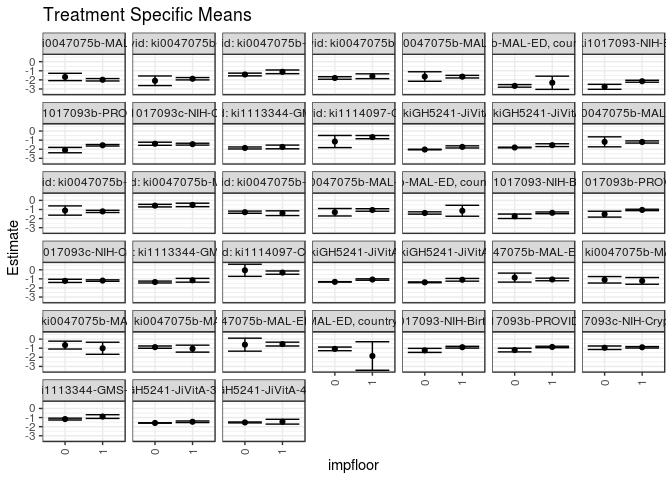

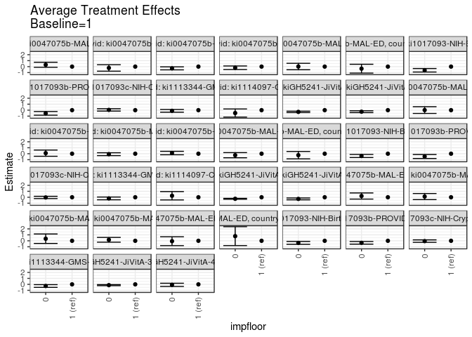

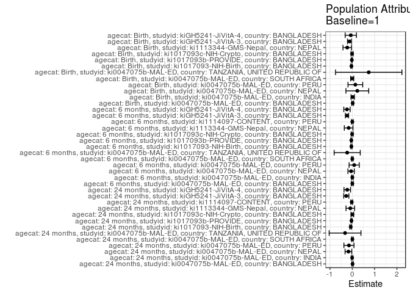

## Results Table

### Parameter: TSM

| agecat | studyid | country | intervention_level | baseline_level | estimate | ci_lower | ci_upper |
| --- | --- | --- | --- | --- | --- | --- | --- |
| Birth | ki0047075b-MAL-ED | BANGLADESH | 1 | NA | -1.0698476 | -1.2125831 | -0.9271121 |
| Birth | ki0047075b-MAL-ED | BANGLADESH | 0 | NA | -0.8615491 | -1.3564328 | -0.3666653 |
| Birth | ki0047075b-MAL-ED | INDIA | 1 | NA | -1.2242857 | -1.5919558 | -0.8566156 |
| Birth | ki0047075b-MAL-ED | INDIA | 0 | NA | -1.1066667 | -1.4622060 | -0.7511274 |
| Birth | ki0047075b-MAL-ED | NEPAL | 1 | NA | -1.0066667 | -1.6704675 | -0.3428658 |
| Birth | ki0047075b-MAL-ED | NEPAL | 0 | NA | -0.6568750 | -1.0897018 | -0.2240482 |
| Birth | ki0047075b-MAL-ED | PERU | 1 | NA | -1.0499202 | -1.4326886 | -0.6671518 |
| Birth | ki0047075b-MAL-ED | PERU | 0 | NA | -0.8821078 | -1.0058486 | -0.7583670 |
| Birth | ki0047075b-MAL-ED | SOUTH AFRICA | 1 | NA | -0.5463218 | -0.7573107 | -0.3353330 |
| Birth | ki0047075b-MAL-ED | SOUTH AFRICA | 0 | NA | -0.6111111 | -1.3247632 | 0.1025410 |
| Birth | ki0047075b-MAL-ED | TANZANIA, UNITED REPUBLIC OF | 1 | NA | -1.8571429 | -3.4252117 | -0.2890740 |
| Birth | ki0047075b-MAL-ED | TANZANIA, UNITED REPUBLIC OF | 0 | NA | -1.0753571 | -1.2760805 | -0.8746338 |
| Birth | ki1017093-NIH-Birth | BANGLADESH | 1 | NA | -0.8895471 | -0.9846275 | -0.7944667 |
| Birth | ki1017093-NIH-Birth | BANGLADESH | 0 | NA | -1.2401912 | -1.4618632 | -1.0185192 |
| Birth | ki1017093b-PROVIDE | BANGLADESH | 1 | NA | -0.8635477 | -0.9425022 | -0.7845931 |
| Birth | ki1017093b-PROVIDE | BANGLADESH | 0 | NA | -1.2036780 | -1.4077118 | -0.9996443 |
| Birth | ki1017093c-NIH-Crypto | BANGLADESH | 1 | NA | -0.8978585 | -0.9775221 | -0.8181949 |
| Birth | ki1017093c-NIH-Crypto | BANGLADESH | 0 | NA | -0.9498859 | -1.1413065 | -0.7584652 |
| Birth | ki1113344-GMS-Nepal | NEPAL | 1 | NA | -0.8896519 | -1.0930750 | -0.6862288 |
| Birth | ki1113344-GMS-Nepal | NEPAL | 0 | NA | -1.1660483 | -1.2677539 | -1.0643427 |
| Birth | kiGH5241-JiVitA-3 | BANGLADESH | 1 | NA | -1.4612628 | -1.5506275 | -1.3718981 |
| Birth | kiGH5241-JiVitA-3 | BANGLADESH | 0 | NA | -1.5939930 | -1.6139029 | -1.5740830 |
| Birth | kiGH5241-JiVitA-4 | BANGLADESH | 1 | NA | -1.4540497 | -1.7174294 | -1.1906701 |
| Birth | kiGH5241-JiVitA-4 | BANGLADESH | 0 | NA | -1.5365101 | -1.5886589 | -1.4843613 |
| 6 months | ki0047075b-MAL-ED | BANGLADESH | 1 | NA | -1.2038659 | -1.3228846 | -1.0848471 |
| 6 months | ki0047075b-MAL-ED | BANGLADESH | 0 | NA | -1.1891865 | -1.7393183 | -0.6390548 |
| 6 months | ki0047075b-MAL-ED | INDIA | 1 | NA | -1.2090618 | -1.3305773 | -1.0875463 |
| 6 months | ki0047075b-MAL-ED | INDIA | 0 | NA | -1.1148447 | -1.6225143 | -0.6071751 |
| 6 months | ki0047075b-MAL-ED | NEPAL | 1 | NA | -0.4994623 | -0.6902770 | -0.3086475 |
| 6 months | ki0047075b-MAL-ED | NEPAL | 0 | NA | -0.5769974 | -0.7199934 | -0.4340014 |
| 6 months | ki0047075b-MAL-ED | PERU | 1 | NA | -1.4082047 | -1.6697804 | -1.1466289 |
| 6 months | ki0047075b-MAL-ED | PERU | 0 | NA | -1.2957412 | -1.4155629 | -1.1759195 |
| 6 months | ki0047075b-MAL-ED | SOUTH AFRICA | 1 | NA | -1.0549689 | -1.1912850 | -0.9186529 |
| 6 months | ki0047075b-MAL-ED | SOUTH AFRICA | 0 | NA | -1.3042299 | -1.7127669 | -0.8956928 |
| 6 months | ki0047075b-MAL-ED | TANZANIA, UNITED REPUBLIC OF | 1 | NA | -1.1399452 | -1.7416176 | -0.5382728 |
| 6 months | ki0047075b-MAL-ED | TANZANIA, UNITED REPUBLIC OF | 0 | NA | -1.3840247 | -1.5110503 | -1.2569991 |
| 6 months | ki1017093-NIH-Birth | BANGLADESH | 1 | NA | -1.3647235 | -1.4589420 | -1.2705049 |
| 6 months | ki1017093-NIH-Birth | BANGLADESH | 0 | NA | -1.7469473 | -1.9899958 | -1.5038988 |
| 6 months | ki1017093b-PROVIDE | BANGLADESH | 1 | NA | -1.0471883 | -1.1220813 | -0.9722952 |
| 6 months | ki1017093b-PROVIDE | BANGLADESH | 0 | NA | -1.5139693 | -1.8377153 | -1.1902232 |
| 6 months | ki1017093c-NIH-Crypto | BANGLADESH | 1 | NA | -1.1903080 | -1.2710656 | -1.1095505 |
| 6 months | ki1017093c-NIH-Crypto | BANGLADESH | 0 | NA | -1.2214223 | -1.3955683 | -1.0472763 |
| 6 months | ki1113344-GMS-Nepal | NEPAL | 1 | NA | -1.1576125 | -1.3658157 | -0.9494093 |
| 6 months | ki1113344-GMS-Nepal | NEPAL | 0 | NA | -1.3512697 | -1.4526942 | -1.2498453 |
| 6 months | ki1114097-CONTENT | PERU | 1 | NA | -0.3141252 | -0.4953216 | -0.1329287 |
| 6 months | ki1114097-CONTENT | PERU | 0 | NA | -0.0606769 | -0.7290015 | 0.6076478 |
| 6 months | kiGH5241-JiVitA-3 | BANGLADESH | 1 | NA | -1.0751765 | -1.1489918 | -1.0013612 |
| 6 months | kiGH5241-JiVitA-3 | BANGLADESH | 0 | NA | -1.3313777 | -1.3551800 | -1.3075754 |
| 6 months | kiGH5241-JiVitA-4 | BANGLADESH | 1 | NA | -1.1043321 | -1.2555701 | -0.9530941 |
| 6 months | kiGH5241-JiVitA-4 | BANGLADESH | 0 | NA | -1.3803293 | -1.4203443 | -1.3403143 |
| 24 months | ki0047075b-MAL-ED | BANGLADESH | 1 | NA | -1.9899174 | -2.1232202 | -1.8566146 |
| 24 months | ki0047075b-MAL-ED | BANGLADESH | 0 | NA | -1.6808067 | -2.0820868 | -1.2795266 |
| 24 months | ki0047075b-MAL-ED | INDIA | 1 | NA | -1.8778631 | -2.0061214 | -1.7496048 |
| 24 months | ki0047075b-MAL-ED | INDIA | 0 | NA | -2.0978277 | -2.6249245 | -1.5707310 |
| 24 months | ki0047075b-MAL-ED | NEPAL | 1 | NA | -1.1179012 | -1.3191247 | -0.9166777 |
| 24 months | ki0047075b-MAL-ED | NEPAL | 0 | NA | -1.4106852 | -1.5618824 | -1.2594881 |
| 24 months | ki0047075b-MAL-ED | PERU | 1 | NA | -1.6017202 | -1.8678571 | -1.3355833 |
| 24 months | ki0047075b-MAL-ED | PERU | 0 | NA | -1.7927688 | -1.9283303 | -1.6572074 |
| 24 months | ki0047075b-MAL-ED | SOUTH AFRICA | 1 | NA | -1.6484182 | -1.7894132 | -1.5074232 |
| 24 months | ki0047075b-MAL-ED | SOUTH AFRICA | 0 | NA | -1.6321020 | -2.1542671 | -1.1099369 |
| 24 months | ki0047075b-MAL-ED | TANZANIA, UNITED REPUBLIC OF | 1 | NA | -2.3179698 | -3.0447579 | -1.5911818 |
| 24 months | ki0047075b-MAL-ED | TANZANIA, UNITED REPUBLIC OF | 0 | NA | -2.6626778 | -2.8036999 | -2.5216557 |
| 24 months | ki1017093-NIH-Birth | BANGLADESH | 1 | NA | -2.1527213 | -2.2607856 | -2.0446570 |
| 24 months | ki1017093-NIH-Birth | BANGLADESH | 0 | NA | -2.7637254 | -3.0372135 | -2.4902373 |
| 24 months | ki1017093b-PROVIDE | BANGLADESH | 1 | NA | -1.5638007 | -1.6488376 | -1.4787639 |
| 24 months | ki1017093b-PROVIDE | BANGLADESH | 0 | NA | -2.0942682 | -2.3888919 | -1.7996445 |
| 24 months | ki1017093c-NIH-Crypto | BANGLADESH | 1 | NA | -1.4428047 | -1.5453510 | -1.3402584 |
| 24 months | ki1017093c-NIH-Crypto | BANGLADESH | 0 | NA | -1.3989976 | -1.5689804 | -1.2290149 |
| 24 months | ki1113344-GMS-Nepal | NEPAL | 1 | NA | -1.7490587 | -1.9524071 | -1.5457103 |
| 24 months | ki1113344-GMS-Nepal | NEPAL | 0 | NA | -1.8605473 | -1.9693126 | -1.7517820 |
| 24 months | ki1114097-CONTENT | PERU | 1 | NA | -0.6702276 | -0.8477407 | -0.4927144 |
| 24 months | ki1114097-CONTENT | PERU | 0 | NA | -1.1539591 | -1.8204713 | -0.4874469 |
| 24 months | kiGH5241-JiVitA-3 | BANGLADESH | 1 | NA | -1.7438114 | -1.8601155 | -1.6275073 |
| 24 months | kiGH5241-JiVitA-3 | BANGLADESH | 0 | NA | -2.0333293 | -2.0621222 | -2.0045364 |
| 24 months | kiGH5241-JiVitA-4 | BANGLADESH | 1 | NA | -1.5534797 | -1.7080325 | -1.3989269 |
| 24 months | kiGH5241-JiVitA-4 | BANGLADESH | 0 | NA | -1.8099494 | -1.8471787 | -1.7727200 |

### Parameter: E(Y)

| agecat | studyid | country | intervention_level | baseline_level | estimate | ci_lower | ci_upper |
| --- | --- | --- | --- | --- | --- | --- | --- |
| Birth | ki0047075b-MAL-ED | BANGLADESH | NA | NA | -1.0530516 | -1.1896058 | -0.9164975 |
| Birth | ki0047075b-MAL-ED | INDIA | NA | NA | -1.2070732 | -1.5254820 | -0.8886644 |
| Birth | ki0047075b-MAL-ED | NEPAL | NA | NA | -0.7828000 | -1.1547571 | -0.4108429 |
| Birth | ki0047075b-MAL-ED | PERU | NA | NA | -0.9141395 | -1.0364098 | -0.7918693 |
| Birth | ki0047075b-MAL-ED | SOUTH AFRICA | NA | NA | -0.5523958 | -0.7550074 | -0.3497843 |
| Birth | ki0047075b-MAL-ED | TANZANIA, UNITED REPUBLIC OF | NA | NA | -1.1213445 | -1.3341800 | -0.9085090 |
| Birth | ki1017093-NIH-Birth | BANGLADESH | NA | NA | -0.9289256 | -1.0178691 | -0.8399821 |
| Birth | ki1017093b-PROVIDE | BANGLADESH | NA | NA | -0.8851020 | -0.9601332 | -0.8100709 |
| Birth | ki1017093c-NIH-Crypto | BANGLADESH | NA | NA | -0.9094945 | -0.9809370 | -0.8380521 |
| Birth | ki1113344-GMS-Nepal | NEPAL | NA | NA | -1.1177022 | -1.2075344 | -1.0278700 |
| Birth | kiGH5241-JiVitA-3 | BANGLADESH | NA | NA | -1.5895451 | -1.6088186 | -1.5702715 |
| Birth | kiGH5241-JiVitA-4 | BANGLADESH | NA | NA | -1.5236135 | -1.5727559 | -1.4744711 |
| 6 months | ki0047075b-MAL-ED | BANGLADESH | NA | NA | -1.2026806 | -1.3203025 | -1.0850586 |
| 6 months | ki0047075b-MAL-ED | INDIA | NA | NA | -1.2070638 | -1.3255909 | -1.0885368 |
| 6 months | ki0047075b-MAL-ED | NEPAL | NA | NA | -0.5534862 | -0.6681825 | -0.4387899 |
| 6 months | ki0047075b-MAL-ED | PERU | NA | NA | -1.3248549 | -1.4336721 | -1.2160378 |
| 6 months | ki0047075b-MAL-ED | SOUTH AFRICA | NA | NA | -1.0547925 | -1.1843544 | -0.9252306 |
| 6 months | ki0047075b-MAL-ED | TANZANIA, UNITED REPUBLIC OF | NA | NA | -1.3700408 | -1.4930436 | -1.2470380 |
| 6 months | ki1017093-NIH-Birth | BANGLADESH | NA | NA | -1.4060639 | -1.4948910 | -1.3172368 |
| 6 months | ki1017093b-PROVIDE | BANGLADESH | NA | NA | -1.0916915 | -1.1661176 | -1.0172654 |
| 6 months | ki1017093c-NIH-Crypto | BANGLADESH | NA | NA | -1.1986783 | -1.2700937 | -1.1272630 |
| 6 months | ki1113344-GMS-Nepal | NEPAL | NA | NA | -1.3225094 | -1.4115793 | -1.2334396 |
| 6 months | ki1114097-CONTENT | PERU | NA | NA | -0.3139217 | -0.4868486 | -0.1409948 |
| 6 months | kiGH5241-JiVitA-3 | BANGLADESH | NA | NA | -1.3134597 | -1.3365976 | -1.2903219 |
| 6 months | kiGH5241-JiVitA-4 | BANGLADESH | NA | NA | -1.3440174 | -1.3812821 | -1.3067527 |
| 24 months | ki0047075b-MAL-ED | BANGLADESH | NA | NA | -1.9783962 | -2.1050210 | -1.8517715 |
| 24 months | ki0047075b-MAL-ED | INDIA | NA | NA | -1.8861894 | -2.0110006 | -1.7613783 |
| 24 months | ki0047075b-MAL-ED | NEPAL | NA | NA | -1.2928054 | -1.4146944 | -1.1709164 |
| 24 months | ki0047075b-MAL-ED | PERU | NA | NA | -1.7524710 | -1.8736426 | -1.6312994 |
| 24 months | ki0047075b-MAL-ED | SOUTH AFRICA | NA | NA | -1.6450595 | -1.7797240 | -1.5103950 |
| 24 months | ki0047075b-MAL-ED | TANZANIA, UNITED REPUBLIC OF | NA | NA | -2.6432311 | -2.7795797 | -2.5068826 |
| 24 months | ki1017093-NIH-Birth | BANGLADESH | NA | NA | -2.2235968 | -2.3265592 | -2.1206344 |
| 24 months | ki1017093b-PROVIDE | BANGLADESH | NA | NA | -1.6024221 | -1.6857420 | -1.5191023 |
| 24 months | ki1017093c-NIH-Crypto | BANGLADESH | NA | NA | -1.4412646 | -1.5249156 | -1.3576135 |
| 24 months | ki1113344-GMS-Nepal | NEPAL | NA | NA | -1.8396747 | -1.9349390 | -1.7444104 |
| 24 months | ki1114097-CONTENT | PERU | NA | NA | -0.6962195 | -0.8674103 | -0.5250287 |
| 24 months | kiGH5241-JiVitA-3 | BANGLADESH | NA | NA | -2.0134592 | -2.0410825 | -1.9858359 |
| 24 months | kiGH5241-JiVitA-4 | BANGLADESH | NA | NA | -1.7804046 | -1.8159135 | -1.7448956 |

### Parameter: ATE

| agecat | studyid | country | intervention_level | baseline_level | estimate | ci_lower | ci_upper |
| --- | --- | --- | --- | --- | --- | --- | --- |
| Birth | ki0047075b-MAL-ED | BANGLADESH | 1 | 1 | 0.0000000 | 0.0000000 | 0.0000000 |
| Birth | ki0047075b-MAL-ED | BANGLADESH | 0 | 1 | 0.2082986 | -0.3073754 | 0.7239726 |
| Birth | ki0047075b-MAL-ED | INDIA | 1 | 1 | 0.0000000 | 0.0000000 | 0.0000000 |
| Birth | ki0047075b-MAL-ED | INDIA | 0 | 1 | 0.1176190 | -0.3938392 | 0.6290772 |
| Birth | ki0047075b-MAL-ED | NEPAL | 1 | 1 | 0.0000000 | 0.0000000 | 0.0000000 |
| Birth | ki0047075b-MAL-ED | NEPAL | 0 | 1 | 0.3497917 | -0.4426543 | 1.1422376 |
| Birth | ki0047075b-MAL-ED | PERU | 1 | 1 | 0.0000000 | 0.0000000 | 0.0000000 |
| Birth | ki0047075b-MAL-ED | PERU | 0 | 1 | 0.1678124 | -0.2323796 | 0.5680044 |
| Birth | ki0047075b-MAL-ED | SOUTH AFRICA | 1 | 1 | 0.0000000 | 0.0000000 | 0.0000000 |
| Birth | ki0047075b-MAL-ED | SOUTH AFRICA | 0 | 1 | -0.0647893 | -0.8089772 | 0.6793986 |
| Birth | ki0047075b-MAL-ED | TANZANIA, UNITED REPUBLIC OF | 1 | 1 | 0.0000000 | 0.0000000 | 0.0000000 |
| Birth | ki0047075b-MAL-ED | TANZANIA, UNITED REPUBLIC OF | 0 | 1 | 0.7817857 | -0.7990779 | 2.3626493 |
| Birth | ki1017093-NIH-Birth | BANGLADESH | 1 | 1 | 0.0000000 | 0.0000000 | 0.0000000 |
| Birth | ki1017093-NIH-Birth | BANGLADESH | 0 | 1 | -0.3506440 | -0.5903388 | -0.1109493 |
| Birth | ki1017093b-PROVIDE | BANGLADESH | 1 | 1 | 0.0000000 | 0.0000000 | 0.0000000 |
| Birth | ki1017093b-PROVIDE | BANGLADESH | 0 | 1 | -0.3401303 | -0.5588439 | -0.1214168 |
| Birth | ki1017093c-NIH-Crypto | BANGLADESH | 1 | 1 | 0.0000000 | 0.0000000 | 0.0000000 |
| Birth | ki1017093c-NIH-Crypto | BANGLADESH | 0 | 1 | -0.0520274 | -0.2589300 | 0.1548752 |
| Birth | ki1113344-GMS-Nepal | NEPAL | 1 | 1 | 0.0000000 | 0.0000000 | 0.0000000 |
| Birth | ki1113344-GMS-Nepal | NEPAL | 0 | 1 | -0.2763964 | -0.5041455 | -0.0486473 |
| Birth | kiGH5241-JiVitA-3 | BANGLADESH | 1 | 1 | 0.0000000 | 0.0000000 | 0.0000000 |
| Birth | kiGH5241-JiVitA-3 | BANGLADESH | 0 | 1 | -0.1327302 | -0.2228901 | -0.0425702 |
| Birth | kiGH5241-JiVitA-4 | BANGLADESH | 1 | 1 | 0.0000000 | 0.0000000 | 0.0000000 |
| Birth | kiGH5241-JiVitA-4 | BANGLADESH | 0 | 1 | -0.0824604 | -0.3501328 | 0.1852121 |
| 6 months | ki0047075b-MAL-ED | BANGLADESH | 1 | 1 | 0.0000000 | 0.0000000 | 0.0000000 |
| 6 months | ki0047075b-MAL-ED | BANGLADESH | 0 | 1 | 0.0146793 | -0.5484195 | 0.5777782 |
| 6 months | ki0047075b-MAL-ED | INDIA | 1 | 1 | 0.0000000 | 0.0000000 | 0.0000000 |
| 6 months | ki0047075b-MAL-ED | INDIA | 0 | 1 | 0.0942170 | -0.4278829 | 0.6163170 |
| 6 months | ki0047075b-MAL-ED | NEPAL | 1 | 1 | 0.0000000 | 0.0000000 | 0.0000000 |
| 6 months | ki0047075b-MAL-ED | NEPAL | 0 | 1 | -0.0775351 | -0.3167557 | 0.1616856 |
| 6 months | ki0047075b-MAL-ED | PERU | 1 | 1 | 0.0000000 | 0.0000000 | 0.0000000 |
| 6 months | ki0047075b-MAL-ED | PERU | 0 | 1 | 0.1124634 | -0.1756562 | 0.4005830 |
| 6 months | ki0047075b-MAL-ED | SOUTH AFRICA | 1 | 1 | 0.0000000 | 0.0000000 | 0.0000000 |
| 6 months | ki0047075b-MAL-ED | SOUTH AFRICA | 0 | 1 | -0.2492609 | -0.6823570 | 0.1838351 |
| 6 months | ki0047075b-MAL-ED | TANZANIA, UNITED REPUBLIC OF | 1 | 1 | 0.0000000 | 0.0000000 | 0.0000000 |
| 6 months | ki0047075b-MAL-ED | TANZANIA, UNITED REPUBLIC OF | 0 | 1 | -0.2440795 | -0.8593891 | 0.3712301 |
| 6 months | ki1017093-NIH-Birth | BANGLADESH | 1 | 1 | 0.0000000 | 0.0000000 | 0.0000000 |
| 6 months | ki1017093-NIH-Birth | BANGLADESH | 0 | 1 | -0.3822239 | -0.6419233 | -0.1225244 |
| 6 months | ki1017093b-PROVIDE | BANGLADESH | 1 | 1 | 0.0000000 | 0.0000000 | 0.0000000 |
| 6 months | ki1017093b-PROVIDE | BANGLADESH | 0 | 1 | -0.4667810 | -0.7993119 | -0.1342501 |
| 6 months | ki1017093c-NIH-Crypto | BANGLADESH | 1 | 1 | 0.0000000 | 0.0000000 | 0.0000000 |
| 6 months | ki1017093c-NIH-Crypto | BANGLADESH | 0 | 1 | -0.0311143 | -0.2231257 | 0.1608971 |
| 6 months | ki1113344-GMS-Nepal | NEPAL | 1 | 1 | 0.0000000 | 0.0000000 | 0.0000000 |
| 6 months | ki1113344-GMS-Nepal | NEPAL | 0 | 1 | -0.1936572 | -0.4269302 | 0.0396157 |
| 6 months | ki1114097-CONTENT | PERU | 1 | 1 | 0.0000000 | 0.0000000 | 0.0000000 |
| 6 months | ki1114097-CONTENT | PERU | 0 | 1 | 0.2534483 | -0.4459075 | 0.9528042 |
| 6 months | kiGH5241-JiVitA-3 | BANGLADESH | 1 | 1 | 0.0000000 | 0.0000000 | 0.0000000 |
| 6 months | kiGH5241-JiVitA-3 | BANGLADESH | 0 | 1 | -0.2562012 | -0.3321502 | -0.1802522 |
| 6 months | kiGH5241-JiVitA-4 | BANGLADESH | 1 | 1 | 0.0000000 | 0.0000000 | 0.0000000 |
| 6 months | kiGH5241-JiVitA-4 | BANGLADESH | 0 | 1 | -0.2759972 | -0.4290405 | -0.1229540 |
| 24 months | ki0047075b-MAL-ED | BANGLADESH | 1 | 1 | 0.0000000 | 0.0000000 | 0.0000000 |
| 24 months | ki0047075b-MAL-ED | BANGLADESH | 0 | 1 | 0.3091107 | -0.1120813 | 0.7303027 |
| 24 months | ki0047075b-MAL-ED | INDIA | 1 | 1 | 0.0000000 | 0.0000000 | 0.0000000 |
| 24 months | ki0047075b-MAL-ED | INDIA | 0 | 1 | -0.2199647 | -0.7619615 | 0.3220322 |
| 24 months | ki0047075b-MAL-ED | NEPAL | 1 | 1 | 0.0000000 | 0.0000000 | 0.0000000 |
| 24 months | ki0047075b-MAL-ED | NEPAL | 0 | 1 | -0.2927840 | -0.5456164 | -0.0399516 |
| 24 months | ki0047075b-MAL-ED | PERU | 1 | 1 | 0.0000000 | 0.0000000 | 0.0000000 |
| 24 months | ki0047075b-MAL-ED | PERU | 0 | 1 | -0.1910487 | -0.4905988 | 0.1085014 |
| 24 months | ki0047075b-MAL-ED | SOUTH AFRICA | 1 | 1 | 0.0000000 | 0.0000000 | 0.0000000 |
| 24 months | ki0047075b-MAL-ED | SOUTH AFRICA | 0 | 1 | 0.0163162 | -0.5249318 | 0.5575641 |
| 24 months | ki0047075b-MAL-ED | TANZANIA, UNITED REPUBLIC OF | 1 | 1 | 0.0000000 | 0.0000000 | 0.0000000 |
| 24 months | ki0047075b-MAL-ED | TANZANIA, UNITED REPUBLIC OF | 0 | 1 | -0.3447080 | -1.0844455 | 0.3950295 |
| 24 months | ki1017093-NIH-Birth | BANGLADESH | 1 | 1 | 0.0000000 | 0.0000000 | 0.0000000 |
| 24 months | ki1017093-NIH-Birth | BANGLADESH | 0 | 1 | -0.6110041 | -0.9028135 | -0.3191947 |
| 24 months | ki1017093b-PROVIDE | BANGLADESH | 1 | 1 | 0.0000000 | 0.0000000 | 0.0000000 |
| 24 months | ki1017093b-PROVIDE | BANGLADESH | 0 | 1 | -0.5304675 | -0.8366914 | -0.2242436 |
| 24 months | ki1017093c-NIH-Crypto | BANGLADESH | 1 | 1 | 0.0000000 | 0.0000000 | 0.0000000 |
| 24 months | ki1017093c-NIH-Crypto | BANGLADESH | 0 | 1 | 0.0438071 | -0.1532812 | 0.2408953 |
| 24 months | ki1113344-GMS-Nepal | NEPAL | 1 | 1 | 0.0000000 | 0.0000000 | 0.0000000 |
| 24 months | ki1113344-GMS-Nepal | NEPAL | 0 | 1 | -0.1114886 | -0.3418936 | 0.1189164 |
| 24 months | ki1114097-CONTENT | PERU | 1 | 1 | 0.0000000 | 0.0000000 | 0.0000000 |
| 24 months | ki1114097-CONTENT | PERU | 0 | 1 | -0.4837315 | -1.1721725 | 0.2047094 |
| 24 months | kiGH5241-JiVitA-3 | BANGLADESH | 1 | 1 | 0.0000000 | 0.0000000 | 0.0000000 |
| 24 months | kiGH5241-JiVitA-3 | BANGLADESH | 0 | 1 | -0.2895179 | -0.4091892 | -0.1698465 |
| 24 months | kiGH5241-JiVitA-4 | BANGLADESH | 1 | 1 | 0.0000000 | 0.0000000 | 0.0000000 |
| 24 months | kiGH5241-JiVitA-4 | BANGLADESH | 0 | 1 | -0.2564697 | -0.4126799 | -0.1002595 |

### Parameter: PAR

| agecat | studyid | country | intervention_level | baseline_level | estimate | ci_lower | ci_upper |
| --- | --- | --- | --- | --- | --- | --- | --- |
| Birth | ki0047075b-MAL-ED | BANGLADESH | 1 | NA | 0.0167960 | -0.0227614 | 0.0563533 |
| Birth | ki0047075b-MAL-ED | INDIA | 1 | NA | 0.0172125 | -0.0587357 | 0.0931607 |
| Birth | ki0047075b-MAL-ED | NEPAL | 1 | NA | 0.2238667 | -0.2877278 | 0.7354611 |
| Birth | ki0047075b-MAL-ED | PERU | 1 | NA | 0.1357807 | -0.1940377 | 0.4655990 |
| Birth | ki0047075b-MAL-ED | SOUTH AFRICA | 1 | NA | -0.0060740 | -0.0759449 | 0.0637969 |
| Birth | ki0047075b-MAL-ED | TANZANIA, UNITED REPUBLIC OF | 1 | NA | 0.7357983 | -0.7524434 | 2.2240401 |
| Birth | ki1017093-NIH-Birth | BANGLADESH | 1 | NA | -0.0393785 | -0.0698818 | -0.0088752 |
| Birth | ki1017093b-PROVIDE | BANGLADESH | 1 | NA | -0.0215544 | -0.0440178 | 0.0009091 |
| Birth | ki1017093c-NIH-Crypto | BANGLADESH | 1 | NA | -0.0116361 | -0.0581702 | 0.0348981 |
| Birth | ki1113344-GMS-Nepal | NEPAL | 1 | NA | -0.2280503 | -0.4192579 | -0.0368427 |
| Birth | kiGH5241-JiVitA-3 | BANGLADESH | 1 | NA | -0.1282823 | -0.2156050 | -0.0409596 |
| Birth | kiGH5241-JiVitA-4 | BANGLADESH | 1 | NA | -0.0695638 | -0.3220885 | 0.1829610 |
| 6 months | ki0047075b-MAL-ED | BANGLADESH | 1 | NA | 0.0011853 | -0.0430206 | 0.0453912 |
| 6 months | ki0047075b-MAL-ED | INDIA | 1 | NA | 0.0019979 | -0.0342853 | 0.0382812 |
| 6 months | ki0047075b-MAL-ED | NEPAL | 1 | NA | -0.0540239 | -0.1963808 | 0.0883330 |
| 6 months | ki0047075b-MAL-ED | PERU | 1 | NA | 0.0833497 | -0.1443659 | 0.3110653 |
| 6 months | ki0047075b-MAL-ED | SOUTH AFRICA | 1 | NA | 0.0001764 | -0.0346381 | 0.0349910 |
| 6 months | ki0047075b-MAL-ED | TANZANIA, UNITED REPUBLIC OF | 1 | NA | -0.2300956 | -0.8157859 | 0.3555947 |
| 6 months | ki1017093-NIH-Birth | BANGLADESH | 1 | NA | -0.0413404 | -0.0717528 | -0.0109279 |
| 6 months | ki1017093b-PROVIDE | BANGLADESH | 1 | NA | -0.0445032 | -0.0731500 | -0.0158565 |
| 6 months | ki1017093c-NIH-Crypto | BANGLADESH | 1 | NA | -0.0083703 | -0.0515290 | 0.0347884 |
| 6 months | ki1113344-GMS-Nepal | NEPAL | 1 | NA | -0.1648969 | -0.3593681 | 0.0295742 |
| 6 months | ki1114097-CONTENT | PERU | 1 | NA | 0.0002035 | -0.0364723 | 0.0368793 |
| 6 months | kiGH5241-JiVitA-3 | BANGLADESH | 1 | NA | -0.2382832 | -0.3110077 | -0.1655588 |
| 6 months | kiGH5241-JiVitA-4 | BANGLADESH | 1 | NA | -0.2396853 | -0.3819187 | -0.0974520 |
| 24 months | ki0047075b-MAL-ED | BANGLADESH | 1 | NA | 0.0115212 | -0.0210009 | 0.0440432 |
| 24 months | ki0047075b-MAL-ED | INDIA | 1 | NA | -0.0083263 | -0.0444352 | 0.0277825 |
| 24 months | ki0047075b-MAL-ED | NEPAL | 1 | NA | -0.1749042 | -0.3252224 | -0.0245860 |
| 24 months | ki0047075b-MAL-ED | PERU | 1 | NA | -0.1507508 | -0.3779678 | 0.0764662 |
| 24 months | ki0047075b-MAL-ED | SOUTH AFRICA | 1 | NA | 0.0033587 | -0.0337148 | 0.0404321 |
| 24 months | ki0047075b-MAL-ED | TANZANIA, UNITED REPUBLIC OF | 1 | NA | -0.3252613 | -1.0387695 | 0.3882470 |
| 24 months | ki1017093-NIH-Birth | BANGLADESH | 1 | NA | -0.0708755 | -0.1097376 | -0.0320133 |
| 24 months | ki1017093b-PROVIDE | BANGLADESH | 1 | NA | -0.0386214 | -0.0654070 | -0.0118358 |
| 24 months | ki1017093c-NIH-Crypto | BANGLADESH | 1 | NA | 0.0015401 | -0.0585746 | 0.0616548 |
| 24 months | ki1113344-GMS-Nepal | NEPAL | 1 | NA | -0.0906160 | -0.2828287 | 0.1015967 |
| 24 months | ki1114097-CONTENT | PERU | 1 | NA | -0.0259919 | -0.0660795 | 0.0140956 |
| 24 months | kiGH5241-JiVitA-3 | BANGLADESH | 1 | NA | -0.2696478 | -0.3849057 | -0.1543899 |
| 24 months | kiGH5241-JiVitA-4 | BANGLADESH | 1 | NA | -0.2269249 | -0.3737116 | -0.0801381 |